# PA2_template - Analasys of Weather Events Across the USA

# Results

## Health impact impact

First of all Let’s see which type of event has caused most of the casualties

```r
tot_health_impact <- tot[,c(1,2,3)]
tot_health_impact <- tot_health_impact[order(-tot_health_impact$fatalities),]
print(tot_health_impact)
```

```
##   EVENT_CATEGORY injuries fatalities
## 6        Tornado    91407       5661
## 4           Heat    14040       3651
## 5          Storm    21211       2772
## 2          Flood     8912       1665
## 7           <NA>     1993        994
## 1           Cold     1594        387
## 3           Hail     1371         15
```

We can clearly see that **Tornados have contributed to most of the casualties** and therefore have had the **biggest impact of Health**

This clearly coralated by the following graph which represent fatalities and injuries historical trend broken down by event type

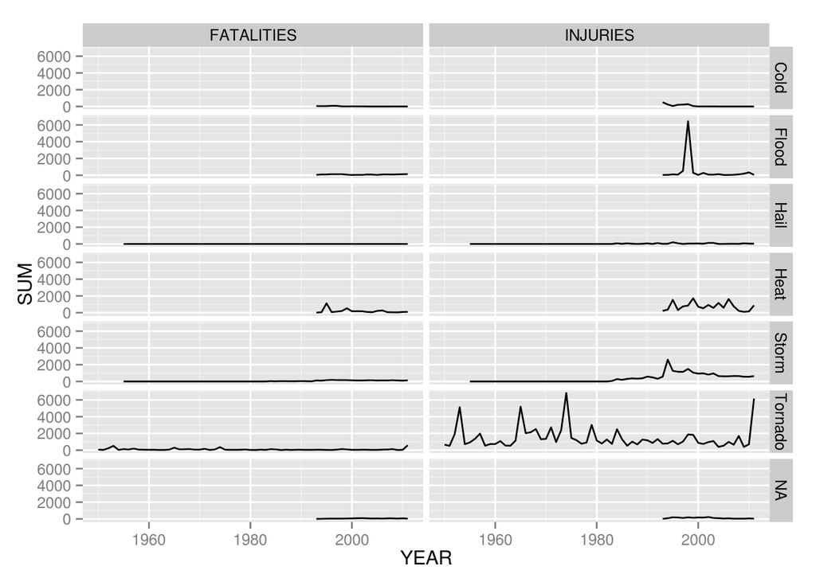

```r
health_impact <- subset(consolidation, consolidation$IMPACT %in% c("INJURIES","FATALITIES"))

qplot(YEAR,SUM,data=health_impact,
             geom=c("line"),
             facets=EVENT_CATEGORY~IMPACT)
```

## Economical Impact

First of all Let’s see which type of event has caused most damages

```r
tot_economic_impact <- tot[,c(1,4,5)]
tot_economic_impact$tot_damage <- tot_economic_impact$prop_damage + tot_economic_impact$crop_damage
tot_economic_impact<- tot_economic_impact[order(-tot_economic_impact$tot_damage),]
print(tot_economic_impact)
```

```
##   EVENT_CATEGORY prop_damage crop_damage tot_damage
## 5          Storm  4052709.75   244568.52 4297278.27
## 6        Tornado  3215851.56   100030.82 3315882.38
## 2          Flood  2438659.52   364005.93 2802665.45
## 3           Hail   689069.78   581418.36 1270488.14
## 4           Heat   332447.18    66920.54  399367.72
## 1           Cold    78021.28    16112.95   94134.23
## 7           <NA>    77740.94     4770.20   82511.14
```

We can clearly see that **Storms have contributed to most of the damages** and therefore have had the **biggest impact of economy**

This clearly coralated by the following graph which represent prop and crop damages historical trend broken down by event type

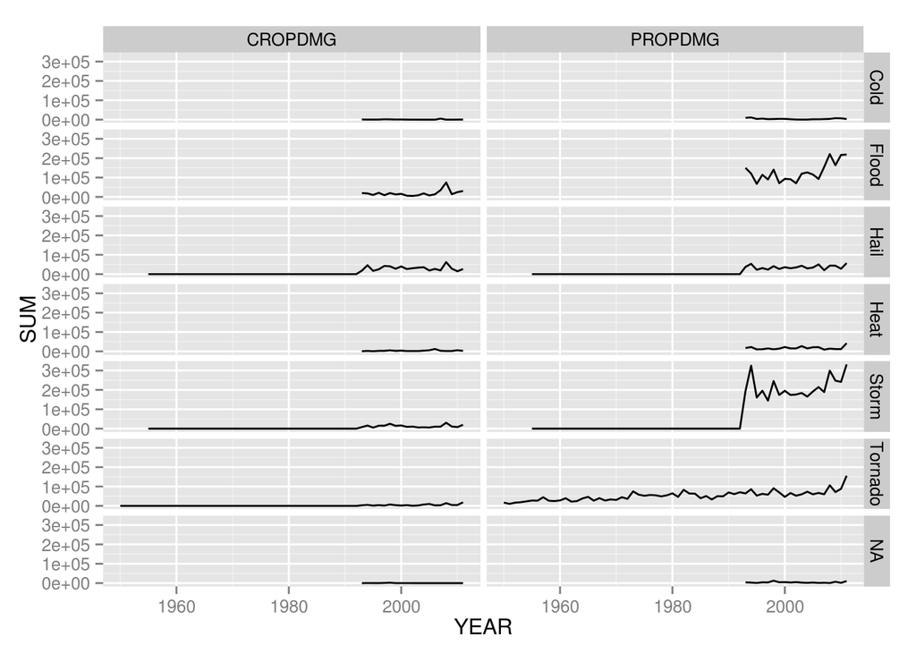

```r
economic_impact <- subset(consolidation, consolidation$IMPACT %in% c("CROPDMG","PROPDMG"))

qplot(YEAR,SUM,data=economic_impact,
             geom=c("line"),
             facets=EVENT_CATEGORY~IMPACT)
```